# Spatial correlation and prediction

\( \newcommand{\E}{{\rm E}} % E expectation operator \newcommand{\Var}{{\rm Var}} % Var variance operator \newcommand{\Cov}{{\rm Cov}} % Cov covariance operator \newcommand{\Cor}{{\rm Corr}} \)

### What is spatial correlation?

Idea from time series: look at lagged correlations, and the \(h\)-scatterplot.

What is it? Plots of (or correlation between) \(Z(s)\) and \(Z(s+h)\), where \(s+h\) is \(s\), shifted by \(h\) (time distance, spatial distance).

### Random variables: expectation, variance, covariance

Random variable: \(Z\) follows a probability distribution, specified by a density function \(f(z)= \Pr(Z=z)\) or a distribution function \(F(z)=\Pr(Z \le z)\)

Expectation: \(\E(Z) = \int_{-\infty}^{\infty} f(s)ds\) – center of mass, mean.

Variance: \(\Var(Z)=\E(Z-\E(Z))^2\) – mean squared distance from mean; measure of spread; square root: standard deviation of \(Z\).

Covariance: \(\Cov(X,Y)=\E((X-\E(X))(Y-\E(Y)))\) – mean product; can be negative; \(\Cov(X,X)=\Var(X)\).

Correlation: \(r_{XY}=\frac{\Cov(X,Y)}{\sqrt{\Var(X)\Var(Y)}}\) – normalized \([-1,1]\) covariance. -1 or +1: perfect correlation.

### Normal distribution

- *univariate*: If \(Z\) follows a normal distribution, its probability distribution is *completely* characterized by its mean \(E(Z)=\mu\) and variance \(\Var(Z)=\sigma^2\)
- *multivariate*: If the vector \(Z=(Z_1,Z_2,…,Z_p)\) follows a *multivariate* normal distribution, its marginal distributions are univariate normal, and its *joint* probability distribution is *completely* characterized by the mean vector \(E(Z)=\mu=(\mu_1,…\mu_p)\) and covariance matrix \(V\), of which element \((i,j)\) equals \(\Cov(Z_i,Z_j)\)
- covariance matrices have variances on the diagonal

```r
library(mvtnorm)
r = 0.0
Sigma = cbind(c(1, r), c(r, 1))
out = rmvnorm(500, c(5,5), Sigma)
x = out[,1]
y = out[,2]
plot(x, y)
model = lm(y~x)
summary(model)
```

```
##
## Call:
## lm(formula = y ~ x)
##
## Residuals:
##     Min      1Q  Median      3Q     Max
## -2.8817 -0.7040 -0.0074  0.6759  3.3342
##
## Coefficients:
##             Estimate Std. Error t value Pr(>|t|)
## (Intercept)  4.61698    0.23017  20.059   <2e-16 ***
## x            0.06078    0.04478   1.358    0.175
## ---
## Signif. codes:  0 '***' 0.001 '**' 0.01 '*' 0.05 '.' 0.1 ' ' 1
##
## Residual standard error: 0.979 on 498 degrees of freedom
## Multiple R-squared:  0.003687,   Adjusted R-squared:  0.001686
## F-statistic: 1.843 on 1 and 498 DF,  p-value: 0.1752
```

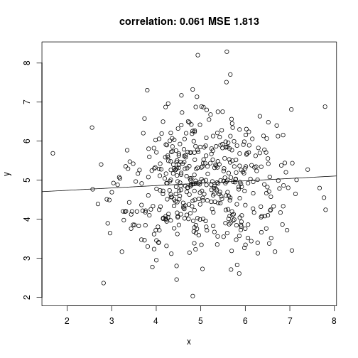

```r
lines(abline(model))
mse = round(mean((x-y)^2), digits=3)
title(paste("correlation:", round(cor(x,y),digits=3), "MSE", mse))
```

```r
r = .5
Sigma = cbind(c(1, r), c(r, 1))
out = rmvnorm(500, c(5,5), Sigma)
x = out[,1]
y = out[,2]
plot(x, y)
model = lm(y~x)
summary(model)
```

```
##
## Call:
## lm(formula = y ~ x)
##
## Residuals:
##      Min       1Q   Median       3Q      Max
## -2.28431 -0.61925 -0.05076  0.62841  2.15376
##
## Coefficients:
##             Estimate Std. Error t value Pr(>|t|)
## (Intercept)  2.45395    0.19410   12.64   <2e-16 ***
## x            0.51349    0.03804   13.50   <2e-16 ***
## ---
## Signif. codes:  0 '***' 0.001 '**' 0.01 '*' 0.05 '.' 0.1 ' ' 1
##
## Residual standard error: 0.8489 on 498 degrees of freedom
## Multiple R-squared:  0.2679, Adjusted R-squared:  0.2664
## F-statistic: 182.2 on 1 and 498 DF,  p-value: < 2.2e-16
```

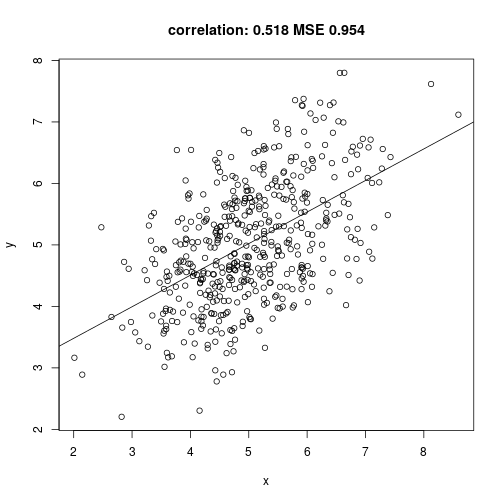

```r
lines(abline(model))
mse = round(mean((x-y)^2), digits=3)
title(paste("correlation:", round(cor(x,y),digits=3), "MSE", mse))
```

```r
r = .9
Sigma = cbind(c(1, r), c(r, 1))
out = rmvnorm(500, c(5,5), Sigma)
x = out[,1]
y = out[,2]
plot(x, y)
model = lm(y~x)
summary(model)
```

```
##
## Call:
## lm(formula = y ~ x)
##
## Residuals:
##      Min       1Q   Median       3Q      Max
## -1.56898 -0.30933  0.01071  0.29787  1.12509
##
## Coefficients:
##             Estimate Std. Error t value Pr(>|t|)
## (Intercept)  0.48709    0.10207   4.772  2.4e-06 ***
## x            0.90374    0.02022  44.701  < 2e-16 ***
## ---
## Signif. codes:  0 '***' 0.001 '**' 0.01 '*' 0.05 '.' 0.1 ' ' 1
##
## Residual standard error: 0.4401 on 498 degrees of freedom
## Multiple R-squared:  0.8005, Adjusted R-squared:  0.8001
## F-statistic:  1998 on 1 and 498 DF,  p-value: < 2.2e-16
```

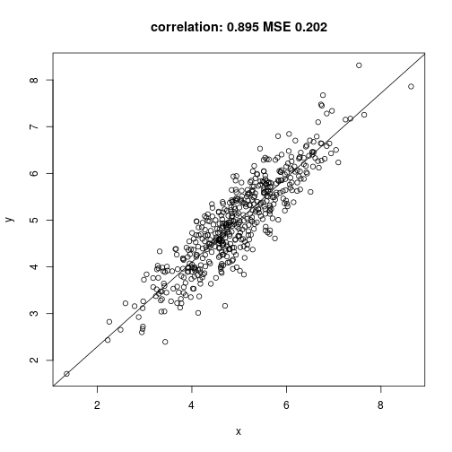

```r
lines(abline(model))
mse = round(mean((x-y)^2), digits=3)
title(paste("correlation:", round(cor(x,y),digits=3), "MSE", mse))
```

```r
r = .95
Sigma = cbind(c(1, r), c(r, 1))
out = rmvnorm(500, c(5,5), Sigma)
x = out[,1]
y = out[,2]
y = x + 0.1 * rnorm(500)
plot(x, y)
model = lm(y~x)
summary(model)
```

```
##
## Call:
## lm(formula = y ~ x)
##
## Residuals:
##      Min       1Q   Median       3Q      Max
## -0.30901 -0.07453 -0.00049  0.07229  0.32907
##
## Coefficients:
##              Estimate Std. Error t value Pr(>|t|)
## (Intercept) -0.009077   0.024034  -0.378    0.706
## x            1.002853   0.004769 210.280   <2e-16 ***
## ---
## Signif. codes:  0 '***' 0.001 '**' 0.01 '*' 0.05 '.' 0.1 ' ' 1
##
## Residual standard error: 0.106 on 498 degrees of freedom
## Multiple R-squared:  0.9889, Adjusted R-squared:  0.9888
## F-statistic: 4.422e+04 on 1 and 498 DF,  p-value: < 2.2e-16
```

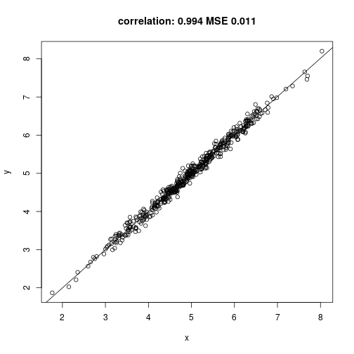

```r
lines(abline(model))
mse = round(mean((x-y)^2), digits=3)
title(paste("correlation:", round(cor(x,y),digits=3), "MSE", mse))
```

### How can correlation help prediction?

Problem:

[figure not shown]

### Questions

Given observation \(z(s_1)\), how to predict \(z(s_0)\)?

- What is the best predicted value at \(s_0\), \(\hat{z}(s_0)\)?
- How can we compute a measure of error for \(\hat{z}(s_0)-z(s_0)\)?
- Can we compute e.g.~95\% prediction intervals for the unknown \(z(s_0)\)?

Obviously, given *only* \(z(s_1)\), the best predictor for \(z(s_0)\) is \(\hat{z}(s_0)=z(s_1)\).

But what is the error variance, i.e. \(\mbox{Var}(\hat{z}(s_0)-z(s_0))\)?

### Estimation error

Let both \(z(s_1)\) and \(z(s_0)\) come from a field that has variance 1, i.e. \(\mbox{Var}(z(s_0)) = \mbox{Var}(z(s_1))=1\), and that has a constant mean: \(\mbox{E}(z(s_0)) = \mbox{E}(z(s_1))=m\)

Then, \[\mbox{Var}(\hat{z}(s_0)-z(s_0)) = \mbox{Var}(z(s_1)-z(s_0))\]

As both have the same mean, this can be written as \[\mbox{E}(\hat{z}(s_0)-z(s_0))^2 = \mbox{Var}(z(s_1)) + \mbox{Var}(z(s_0)) - 2\mbox{Cov}(z(s_1),z(s_0))\]

### Suppose we know the mean

If we know the mean \(\mu\), it may be a good idea to use a compromise between the observation and the mean, e.g. \[\hat{z}(s_0) = (1-r) \mu + r z(s_1)\]

### Next problems…

[figure not shown]

### What is Geostatistical Interpolation?

Geostatistical interpolation (kriging) uses linear predictors \[\hat{z}(s_0) = \sum_{i=1}^n \lambda_i z(s_i)\] with weights chosen such that

- the interpolated values is unbiased: \(\mbox{E}(\hat{z}(s_0)-z(s_0))=0\) and
- has mininum variance: \(\mbox{Var}(\hat{z}(s_0)-z(s_0))\) is at minimum.

All that is needed is variances and correlations.

### Random variables

Random variables (RVs) are numeric variables whose outcomes are subject to chance.

The cumulative distribution of probability \(F_x(\cdot)\) over outcomes \(z\) over all possible values of the RV \(Z\) is the probability distribution function: \[P(Z \le z) = F_Z(z) = \int_{-\infty}^z f_Z(u)du\] where \(f_Z(\cdot)\) is the probability *density* function of \(Z\). The sum of all probability is 1.

Random variables have an expectation (mean): \(E(Z) = \int_{-\infty}^{\infty} u f_Z(u) du\) and a variance: \(\Var(Z) = E[(Z-E(Z))^2]\).

Try to think of \(E(Z)\) as \(\frac{1}{n}\sum_{i=1}^{n} z_i\), with \(i \rightarrow \infty\).

Two random variables \(X\) and \(Y\) have covariance defined as \(\Cov(X,Y) = E[(X-E(X))(Y-E(Y))]\)

### Correlation and covariance

Correlation is scaled covariance, scaled by the variances. For two variables \(X\) and \(Y\), it is \[\Cor(X,Y) = \frac{\Cov(X,Y)}{\sqrt{\Var(X)\Var(Y)}}\]

It is quite easy to show that \(|\Cov(X,Y)| \le \sqrt{\Var(X)\Var(Y)}\), so correlation ranges from -1 to 1. For this, note that \(\Cov(X,X)=\Var(X)\). and \(\Cov(X,-X)=-\Var(X)\).

It is perhaps easier to think of covariance as unscaled correlation.

Note: *A large covariance does not imply a strong correlation*

### The quadratic form

We will not consider single random variables, but rather large collections of them. In fact, we will consider each observation \(z(s_i)\) as a realisation (outcome) of a random variable \(Z(s_i)\), and consider the \(Z\) variable at all other locations also as separate random variables, say \(Z(s_0)\) for any \(s_0\) in the domain of interest.

Let \(Z = [Z(s_1)\ Z(s_2)\ …\ Z(s_n)]‘\) then \(\Var(Z)=V\) is the covariance matrix of vector \(Z\), with \(i,j\)-th element \(\Cov(Z(s_i),Z(s_j))\), implying it has variances on the diagonal.

Then, it is easy to show that for non-random weights \(\lambda = [\lambda_1 … \lambda_n]’\) the quadratic form \(\lambda'Z = \sum_{i=1}^n \lambda_i Z(s_i)\) has variance \[ \Var(\lambda'Z) = \lambda' \Var(Z) \lambda = \sum_{i=1}^n \sum_{j=1}^n \lambda_i \lambda_j \Cov(Z(s_i),Z(s_j)) = \lambda'V\lambda\]

### Why do we need this?

When we predict (interpolate), we're forming linear combinations, \(\sum_{i=1}^n \lambda_i Z(s_i)\), and want to know the variance of \(\sum_{i=1}^n \lambda_i Z(s_i) - Z(s_0)\), the interpolation error variance. Only then can we find weights such that it is minimum.

What is the scalar \(\Var(\sum_{i=1}^n \lambda_i Z(s_i)-Z(s_0))\)? Write as

So, we need variances of all \(Z(s_i)\), including for all \(s_0\), and all covariances between pairs \(Z(s_i)\) and \(Z(s_j)\), including all \(s_0\).

### Suppose we know all that

Kriging: find weights \(\lambda\) such that \(\Var(Z(s_0)-\hat{Z}(s_0))= \Var(Z(s_0)-\sum_{i=1}^n\lambda_i Z(s_i))\) is minimized, and we have the best (minimum variance) linear predictor.

Best linear prediction weights: Let \(V=\Var(Z)\ \ (n\times n)\) and \(v=\Cov(Z(s_0),Z)\ \ (n\times 1)\), and scalar \(\Var(Z(s_0)) = \sigma^2_0\).

Expected squared prediction error \(\E(Z(s_0)-\hat{Z}(s_0))^2 = \sigma^2(s_0)\)

Replace \(Z\) with \(Z-\mu\) (or assume \(\mu=0\))

\[\sigma^2(s_0) = \E(Z(s_0)-\lambda ‘ Z)^2 = \E(Z(s_0))^2 - 2 \lambda ’\E(Z(s_0) Z)+\lambda'\E(Z Z')\lambda \]

\[ = \Var(Z(s_0)) - 2 \lambda'\Cov(Z(s_0),Z) + \lambda'\Var(Z)\lambda = \sigma^2_0 - 2 \lambda'v + \lambda'V\lambda \]

Choose \(\lambda\) such that \(\frac{\delta \sigma^2(s_0)}{\delta\lambda} = -2 v' + 2\lambda'V = 0\)

\(\lambda' = v' V^{-1}\)

BLP/Simple kriging:

1. \(\hat{Z}(s_0) = \mu + v'V^{-1} (Z-\mu)\)
2. \(\sigma^2(s_0) = \sigma^2_0 - v'V^{-1}v\)

```r
library(sp)
cov = function(h) exp(-h)

sk = function(data, newdata, mu, cov) {
    library(sp) # spDists
    V = cov(spDists(data))
    v = cov(spDists(data, newdata))
    mu + t(v) %*% solve(V, data[[1]] - mu)
}

# prediction location at (0,1):
newdata = SpatialPoints(cbind(0,1))

# observation location at (1,1), with attribute value (y) 3:
pts = SpatialPoints(cbind(1,1))
data = SpatialPointsDataFrame(pts, data.frame(z = 3))

sk(data, newdata, 0, cov) # mu = 0
```

```
##          [,1]
## [1,] 1.103638
```

```r
newdata = SpatialPoints(cbind(.1 * 0:20, 1))
sk(data, newdata, 0, cov) # mu = 0
```

```
##           [,1]
##  [1,] 1.103638
##  [2,] 1.219709
##  [3,] 1.347987
##  [4,] 1.489756
##  [5,] 1.646435
##  [6,] 1.819592
##  [7,] 2.010960
##  [8,] 2.222455
##  [9,] 2.456192
## [10,] 2.714512
## [11,] 3.000000
## [12,] 2.714512
## [13,] 2.456192
## [14,] 2.222455
## [15,] 2.010960
## [16,] 1.819592
## [17,] 1.646435
## [18,] 1.489756
## [19,] 1.347987
## [20,] 1.219709
## [21,] 1.103638
```

Plotting them:

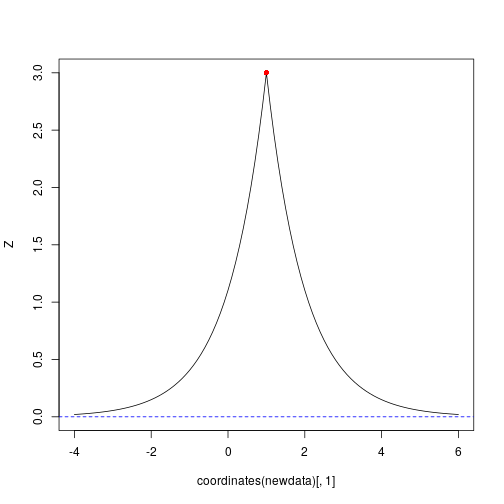

```r
newdata = SpatialPoints(cbind(seq(-4,6,by=.1), 1))
Z = sk(data, newdata, 0, cov) # mu = 0
plot(coordinates(newdata)[,1], Z, type='l', ylim = c(0,3))
points(as(data, "data.frame")[,c(2,1)], col='red', pch=16)
abline(0,0, col='blue', lty=2)
```

Example with zinc data:

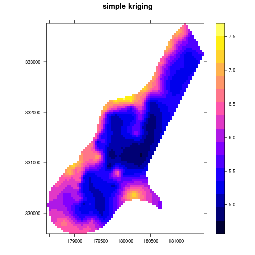

```r
data(meuse, package = "sp")
coordinates(meuse) = ~x+y
data(meuse.grid, package = "sp")
coordinates(meuse.grid) = ~x+y
gridded(meuse.grid) = TRUE
meuse[[1]] = log(meuse$zinc)
meuse.grid$sk = sk(meuse, meuse.grid, mean(log(meuse$zinc)), function(h) exp(-h/300))
spplot(meuse.grid["sk"], main = "simple kriging", scales = list(draw = TRUE))
```